# DDS Case Study 2

Jeremy Otsap

August 11, 2019

## Initial Data Cleaning

First we load the data into a data frame. With over 36 parameters, the immediate goal is to determine which ones contribute any insight.

### Removing Non-contributing Parameters

*Database UniqueID Values* ID and EmployeeNumber do not provide actual data, just unique object identifiers, and are thus candidate for elimination from our analysis

*Uni-valued Parameters* Additionaly several other parameters are candidates for removal from full analysis:

- All rows have “Y” for Over18
- All rows have 1 for EmployeeCount
- All rows have 80 for StandardHours

```r
# loading data
employee.df <- read.csv(
  "https://raw.githubusercontent.com/jotsap/CaseStudy2DDS/master/data/CaseStudy2-data.csv",
  sep = ",",
  header = TRUE)
str(employee.df)
```

```
## 'data.frame':    870 obs. of  36 variables:
##  $ ID                      : int  1 2 3 4 5 6 7 8 9 10 ...
##  $ Age                     : int  32 40 35 32 24 27 41 37 34 34 ...
##  $ Attrition               : Factor w/ 2 levels "No","Yes": 1 1 1 1 1 1 1 1 1 1 ...
##  $ BusinessTravel          : Factor w/ 3 levels "Non-Travel","Travel_Frequently",..: 3 3 2 3 2 2 3 3 3 2 ...
##  $ DailyRate               : int  117 1308 200 801 567 294 1283 309 1333 653 ...
##  $ Department              : Factor w/ 3 levels "Human Resources",..: 3 2 2 3 2 2 2 3 3 2 ...
##  $ DistanceFromHome        : int  13 14 18 1 2 10 5 10 10 10 ...
##  $ Education               : int  4 3 2 4 1 2 5 4 4 4 ...
##  $ EducationField          : Factor w/ 6 levels "Human Resources",..: 2 4 2 3 6 2 4 2 2 6 ...
##  $ EmployeeCount           : int  1 1 1 1 1 1 1 1 1 1 ...
##  $ EmployeeNumber          : int  859 1128 1412 2016 1646 733 1448 1105 1055 1597 ...
##  $ EnvironmentSatisfaction : int  2 3 3 3 1 4 2 4 3 4 ...
##  $ Gender                  : Factor w/ 2 levels "Female","Male": 2 2 2 1 1 2 2 1 1 2 ...
##  $ HourlyRate              : int  73 44 60 48 32 32 90 88 87 92 ...
```

[output cut: 22 more lines]

```r
head(employee.df)
```

```
##   ID Age Attrition    BusinessTravel DailyRate             Department
## 1  1  32        No     Travel_Rarely       117                  Sales
## 2  2  40        No     Travel_Rarely      1308 Research & Development
## 3  3  35        No Travel_Frequently       200 Research & Development
## 4  4  32        No     Travel_Rarely       801                  Sales
## 5  5  24        No Travel_Frequently       567 Research & Development
## 6  6  27        No Travel_Frequently       294 Research & Development
##   DistanceFromHome Education   EducationField EmployeeCount EmployeeNumber
## 1               13         4    Life Sciences             1            859
## 2               14         3          Medical             1           1128
## 3               18         2    Life Sciences             1           1412
## 4                1         4        Marketing             1           2016
## 5                2         1 Technical Degree             1           1646
## 6               10         2    Life Sciences             1            733
##   EnvironmentSatisfaction Gender HourlyRate JobInvolvement JobLevel
```

[output cut: 48 more lines]

```r
# No employees have "N" for 'Over18' parameter
# Thus candidate for elimination
employee.df[employee.df$Over18 != "Y",]
```

```
##  [1] ID                       Age
##  [3] Attrition                BusinessTravel
##  [5] DailyRate                Department
##  [7] DistanceFromHome         Education
##  [9] EducationField           EmployeeCount
## [11] EmployeeNumber           EnvironmentSatisfaction
## [13] Gender                   HourlyRate
## [15] JobInvolvement           JobLevel
## [17] JobRole                  JobSatisfaction
## [19] MaritalStatus            MonthlyIncome
## [21] MonthlyRate              NumCompaniesWorked
## [23] Over18                   OverTime
## [25] PercentSalaryHike        PerformanceRating
## [27] RelationshipSatisfaction StandardHours
## [29] StockOptionLevel         TotalWorkingYears
## [31] TrainingTimesLastYear    WorkLifeBalance
## [33] YearsAtCompany           YearsInCurrentRole
## [35] YearsSinceLastPromotion  YearsWithCurrManager
## <0 rows> (or 0-length row.names)
```

```r
# No employees have a value other than 1
# Thus candidate for elimination
employee.df[employee.df$EmployeeCount != 1,]
```

```
##  [1] ID                       Age
##  [3] Attrition                BusinessTravel
##  [5] DailyRate                Department
##  [7] DistanceFromHome         Education
##  [9] EducationField           EmployeeCount
## [11] EmployeeNumber           EnvironmentSatisfaction
## [13] Gender                   HourlyRate
## [15] JobInvolvement           JobLevel
## [17] JobRole                  JobSatisfaction
## [19] MaritalStatus            MonthlyIncome
## [21] MonthlyRate              NumCompaniesWorked
## [23] Over18                   OverTime
## [25] PercentSalaryHike        PerformanceRating
## [27] RelationshipSatisfaction StandardHours
## [29] StockOptionLevel         TotalWorkingYears
## [31] TrainingTimesLastYear    WorkLifeBalance
## [33] YearsAtCompany           YearsInCurrentRole
## [35] YearsSinceLastPromotion  YearsWithCurrManager
## <0 rows> (or 0-length row.names)
```

```r
# Every employee had '80' for StandardHours
# Thus candidate for elimination
employee.df[employee.df$StandardHours != 80,]
```

```
##  [1] ID                       Age
##  [3] Attrition                BusinessTravel
##  [5] DailyRate                Department
##  [7] DistanceFromHome         Education
##  [9] EducationField           EmployeeCount
## [11] EmployeeNumber           EnvironmentSatisfaction
## [13] Gender                   HourlyRate
## [15] JobInvolvement           JobLevel
## [17] JobRole                  JobSatisfaction
## [19] MaritalStatus            MonthlyIncome
## [21] MonthlyRate              NumCompaniesWorked
## [23] Over18                   OverTime
## [25] PercentSalaryHike        PerformanceRating
## [27] RelationshipSatisfaction StandardHours
## [29] StockOptionLevel         TotalWorkingYears
## [31] TrainingTimesLastYear    WorkLifeBalance
## [33] YearsAtCompany           YearsInCurrentRole
## [35] YearsSinceLastPromotion  YearsWithCurrManager
## <0 rows> (or 0-length row.names)
```

```r
# Placing remaining variables into data frame
emp_clean.df <- employee.df %>% dplyr::select(
  Age,
  Attrition,
  BusinessTravel,
  DailyRate,
  Department,
  DistanceFromHome,
  Education,
  EducationField,
  EnvironmentSatisfaction,
  Gender,
  HourlyRate,
  JobInvolvement,
  JobLevel,
  JobRole,
  JobSatisfaction,
  MaritalStatus,
  MonthlyIncome,
  MonthlyRate,
  NumCompaniesWorked,
  OverTime,
  PercentSalaryHike,
  PerformanceRating,
  RelationshipSatisfaction,
  StockOptionLevel,
  TotalWorkingYears,
  TrainingTimesLastYear,
  WorkLifeBalance,
  YearsAtCompany,
  YearsInCurrentRole,
  YearsSinceLastPromotion,
  YearsWithCurrManager
)

# Checking for missing or "na" values
# none found
table(emp_clean.df %>% is.na())
```

```
##
## FALSE
## 26970
```

### Problem Variables

We have a number of other problematic parameters that we need to address before going into a deeper analysis.

- HourlyRate
- DailyRate
- MonthlyRate

Given that we have no idea what these represent, we need to understand if there is evidence of a relationship with either response MonthlyIncome or Attrition.

A visual analysis of each of HourlyRate, DailyRate, and MonthlyRate show a uniform distribution of all values. Which differs significantly from the right-skewed distribution for Salary, which also has several outliers on the upper bound. [Note also typical of most samples of Salary]

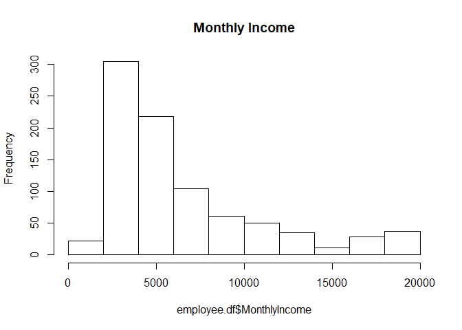

```r
# histogram of MonthlyRate
hist(employee.df$MonthlyIncome, main = "Monthly Income")
```

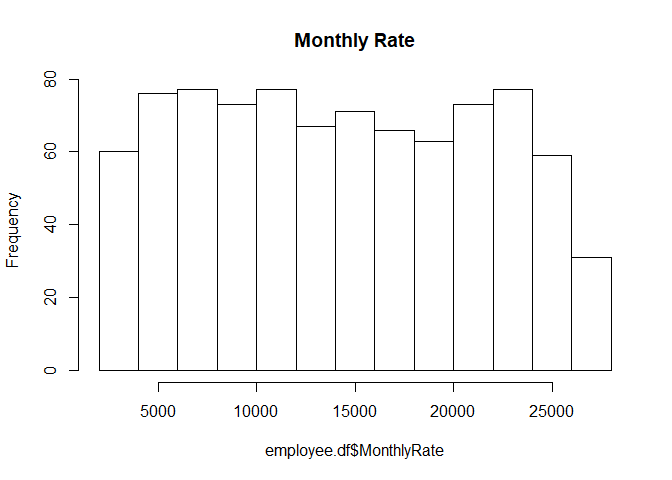

```r
# histogram of MonthlyRate
hist(employee.df$MonthlyRate, main = "Monthly Rate")
```

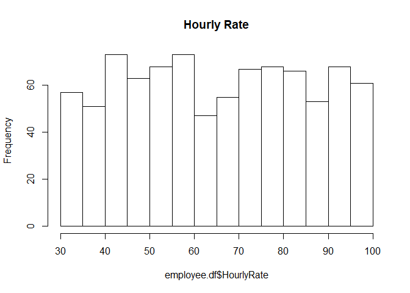

```r
# histogram of HourlyRate
hist(employee.df$HourlyRate, main = "Hourly Rate")
```

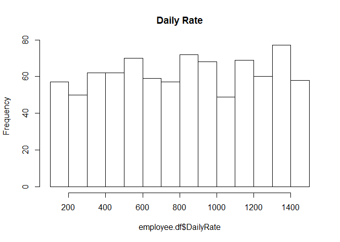

```r
# histogram of DailyRate
hist(employee.df$DailyRate, main = "Daily Rate")
```

When testing for correlation among these parameters, there appears to be no evidence of a correlation to MonthlyIncome vs any of the other three. Note its concerning that additionaly there is no evidence of correlation of DailyRate, HourlyRate, or MonthlyRate to each other. At the very least one should expect to see an employee’s Hourly Rate or Daily Rate have some relation to each other, for instance if these were employees in a consultancy.

```r
# No evidence of correlation between MonthlyRate and HourlyRate
# R value of -0.01603517
cor.test(employee.df$MonthlyRate, employee.df$HourlyRate)
```

```
##
##  Pearson's product-moment correlation
##
## data:  employee.df$MonthlyRate and employee.df$HourlyRate
## t = -0.47249, df = 868, p-value = 0.6367
## alternative hypothesis: true correlation is not equal to 0
## 95 percent confidence interval:
##  -0.08241306  0.05048437
## sample estimates:
##         cor
## -0.01603517
```

```r
# No evidence of correlation between DailyRate and HourlyRate
# R value of 0.04849597
cor.test(employee.df$DailyRate, employee.df$HourlyRate)
```

```
##
##  Pearson's product-moment correlation
##
## data:  employee.df$DailyRate and employee.df$HourlyRate
## t = 1.4305, df = 868, p-value = 0.1529
## alternative hypothesis: true correlation is not equal to 0
## 95 percent confidence interval:
##  -0.01802787  0.11459234
## sample estimates:
##        cor
## 0.04849597
```

```r
# No evidence of correlation between MonthlyRate and DailyRate
# R value of -0.02764077
cor.test(employee.df$MonthlyRate, employee.df$DailyRate)
```

```
##
##  Pearson's product-moment correlation
##
## data:  employee.df$MonthlyRate and employee.df$DailyRate
## t = -0.81466, df = 868, p-value = 0.4155
## alternative hypothesis: true correlation is not equal to 0
## 95 percent confidence interval:
##  -0.09393393  0.03889642
## sample estimates:
##         cor
## -0.02764077
```

```r
# No evidence of correlation between MonthlyRate and MonthlyIncome
# R value of 0.06459407
cor.test(employee.df$MonthlyRate, employee.df$MonthlyIncome)
```

```
##
##  Pearson's product-moment correlation
##
## data:  employee.df$MonthlyRate and employee.df$MonthlyIncome
## t = 1.907, df = 868, p-value = 0.05684
## alternative hypothesis: true correlation is not equal to 0
## 95 percent confidence interval:
##  -0.001879735  0.130499526
## sample estimates:
##        cor
## 0.06459407
```

```r
# No evidence of correlation between MonthlyIncome and HourlyRate
# R value of 0.002391151
cor.test(employee.df$MonthlyIncome, employee.df$HourlyRate)
```

```
##
##  Pearson's product-moment correlation
##
## data:  employee.df$MonthlyIncome and employee.df$HourlyRate
## t = 0.070448, df = 868, p-value = 0.9439
## alternative hypothesis: true correlation is not equal to 0
## 95 percent confidence interval:
##  -0.06408477  0.06884594
## sample estimates:
##         cor
## 0.002391151
```

```r
# No evidence of correlation between MonthlyIncome and DailyRate
# R value of 0.00008790339
cor.test(employee.df$MonthlyIncome, employee.df$DailyRate)
```

```
##
##  Pearson's product-moment correlation
##
## data:  employee.df$MonthlyIncome and employee.df$DailyRate
## t = 0.0025898, df = 868, p-value = 0.9979
## alternative hypothesis: true correlation is not equal to 0
## 95 percent confidence interval:
##  -0.06637822  0.06655325
## sample estimates:
##          cor
## 8.790339e-05
```

When looking at their relationship with Attrition, no clear distinction emerges for HourlyRate, DailyRate, or MonthlyRate. However for MonthlyIncome the distribution visually appears different between the “yes” and “no” groups

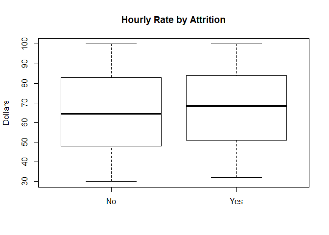

```r
# Attrition vs HourlyRate
boxplot(employee.df$HourlyRate ~ employee.df$Attrition,
        ylab = "Dollars",
        main = "Hourly Rate by Attrition")
```

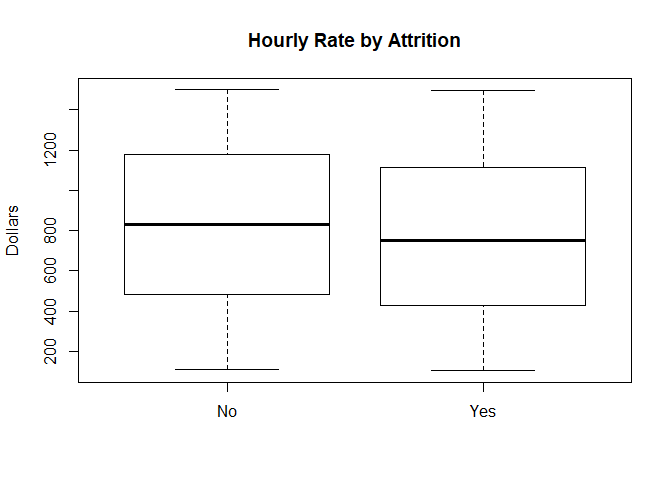

```r
# Attrition vs DailyRate
boxplot(employee.df$DailyRate ~ employee.df$Attrition,
        ylab = "Dollars",
        main = "Hourly Rate by Attrition")
```

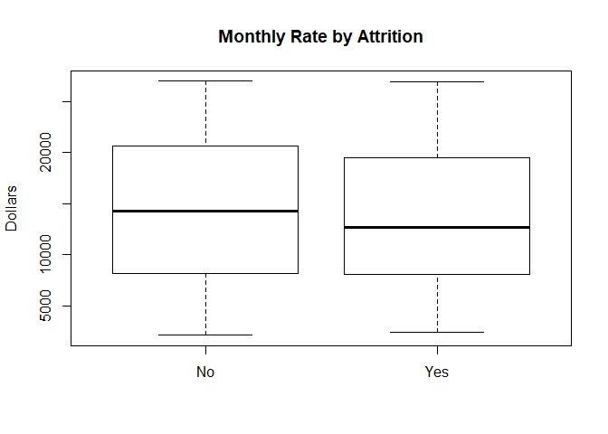

```r
# Attrition vs MonthlyRate
boxplot(employee.df$MonthlyRate ~ employee.df$Attrition,
        ylab = "Dollars",
        main = "Monthly Rate by Attrition")
```

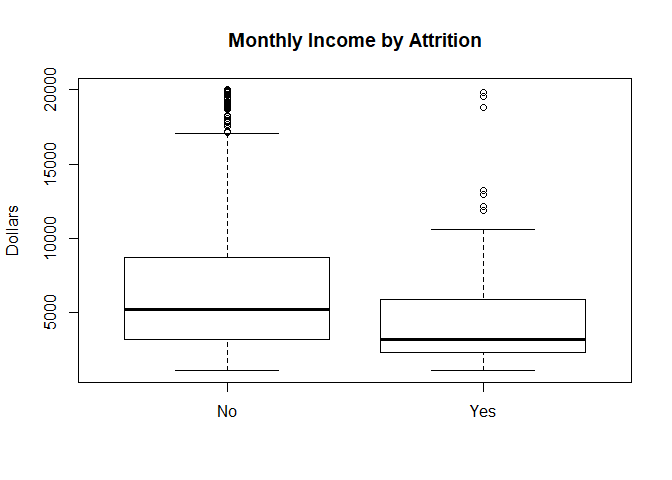

```r
# Attrition vs MonthlyIncome
boxplot(employee.df$MonthlyIncome ~ employee.df$Attrition,
        ylab = "Dollars",
        main = "Monthly Income by Attrition")
```

Lastly, when we do a scatter plot for all combinations of these parameters, no visual patterns emerge.

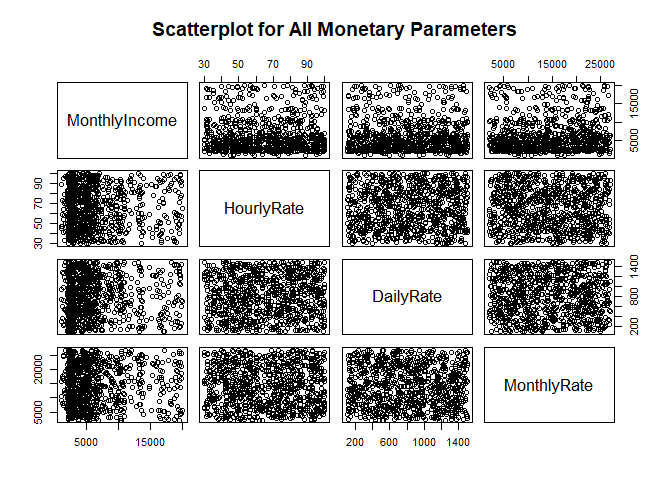

```r
# Pairwise scatterplot
pairs(~ MonthlyIncome + HourlyRate + DailyRate + MonthlyRate,
  data = employee.df,
  main = "Scatterplot for All Monetary Parameters")
```

To clarify, all three of these values allude to some sort of salary. We are are told the *only* value of the three that we do know is MonthlyIncome. HourlyRate, DailyRate and MonthlyRate have no explanation, and if they were related to something similar, such as how much an employee’s billing rate is [i.e. for consultancy], then there should have been a correlation between HourlyRate and DailyRate. Which leads to the larger concern of what do these variables mean and was the data entered correctly

Final analysis will rely ONLY on MonthlyIncome

*PerformanceReview*

This parameter seems to be either incomplete or potentially have erroneous data. Again we have no context for the field, and the only values are 3 or 4

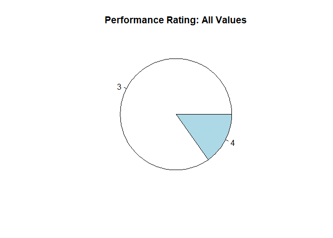

```r
# Treating values as factors not numerics
pie(
  count(employee.df, as.factor(PerformanceRating) )$n,
  labels = count(employee.df, as.factor(PerformanceRating))$"as.factor(PerformanceRating)",
  main = "Performance Rating: All Values"
  )
```

Futhermore there doesn’t appear to be compelling visual evidence of a difference in MonthlyIncome distribution for “4” vs “3” ratings

Given this we will also not be including PerformanceRating in the final analysis.

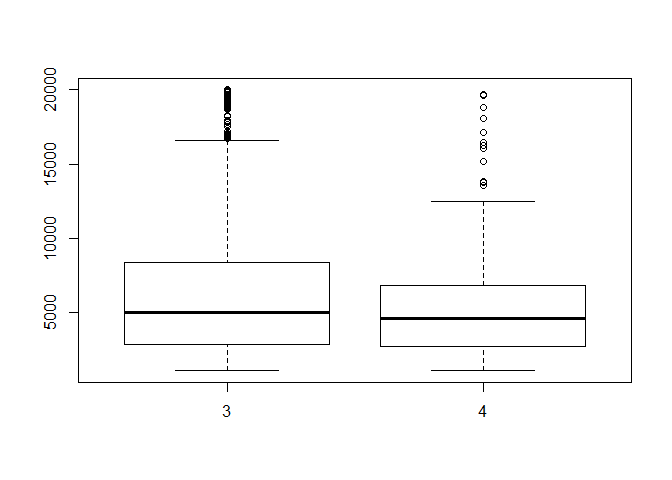

```r
# treating value as factors not numerics
boxplot(employee.df$MonthlyIncome ~ as.factor( employee.df$PerformanceRating))
```

### Cleaned Data Set

Lets create a clean data set in light of our current data exploration. We have reduced the original data frame from 36 parameters down to 27.

```r
# Placing remaining variables into data frame
emp_clean.df <- employee.df %>% dplyr::select(
  MonthlyIncome,
  Attrition,
  Age,
  BusinessTravel,
  Department,
  DistanceFromHome,
  Education,
  EducationField,
  EnvironmentSatisfaction,
  Gender,
  JobInvolvement,
  JobLevel,
  JobRole,
  JobSatisfaction,
  MaritalStatus,
  NumCompaniesWorked,
  OverTime,
  PercentSalaryHike,
  RelationshipSatisfaction,
  StockOptionLevel,
  TotalWorkingYears,
  TrainingTimesLastYear,
  WorkLifeBalance,
  YearsAtCompany,
  YearsInCurrentRole,
  YearsSinceLastPromotion,
  YearsWithCurrManager
)

# Checking for missing or "na" values
# none found
table(emp_clean.df %>% is.na())
```

```
##
## FALSE
## 23490
```

### Data Prep for Income Response Variable

In order to allow us to do categorical analysis for the salary response variable we created a new response variable AnnualIncome based on these different categories:

- $0 - $30,000 annual
- $30,000 - $60,000 annual
- $60,000 - $90,000 annual
- $Over 90,000 annual

We will print out the 10 entries to validate the numerical values for MonthlyIncome are being correctly classified into the correct category for *AnnualIncome* which will be added for final analysis.

```r
# making categories for MonthlyIncome
# $30,000 annual
# $60,000 annual
# $90,000 annual
# $Over 90k annual

cut(emp_clean.df$MonthlyIncome,
    breaks = c(0,2500,5000,7500,999999),
    labels = c("Under_30k","30k_to_60k","60k_to_90k","Over_90k")
    ) -> emp_clean.df$AnnualIncome

# validate accuracy new Annual Income categorical parameter
emp_clean.df[c(1,5,10,15,20,25,30,35,40,45),c("MonthlyIncome","AnnualIncome")]
```

```
##    MonthlyIncome AnnualIncome
## 1           4403   30k_to_60k
## 5           3760   30k_to_60k
## 10          5063   60k_to_90k
## 15          3423   30k_to_60k
## 20          5033   60k_to_90k
## 25          6949   60k_to_90k
## 30          4258   30k_to_60k
## 35          9679     Over_90k
## 40          2791   30k_to_60k
## 45          1223    Under_30k
```

### Data Prep: Categorical & Numeric

To simplify some analytical and graphical exercises, we will create separate data frames for numeric and categoric data

```r
# categoric parameters only
emp_clean.df %>% keep(is.factor) -> emp_clean_factor.df
# put parameter names into vector to verify
emp_clean.df %>% keep(is.factor) %>% names -> catNames
catNames
```

```
## [1] "Attrition"      "BusinessTravel" "Department"     "EducationField"
## [5] "Gender"         "JobRole"        "MaritalStatus"  "OverTime"
## [9] "AnnualIncome"
```

```r
# numeric parameters only
emp_clean.df %>% keep(is.numeric) -> emp_clean_numeric.df
# put parameter names into vector to verify
emp_clean.df %>% keep(is.numeric) %>% names -> numNames
numNames
```

```
##  [1] "MonthlyIncome"            "Age"
##  [3] "DistanceFromHome"         "Education"
##  [5] "EnvironmentSatisfaction"  "JobInvolvement"
##  [7] "JobLevel"                 "JobSatisfaction"
##  [9] "NumCompaniesWorked"       "PercentSalaryHike"
## [11] "RelationshipSatisfaction" "StockOptionLevel"
## [13] "TotalWorkingYears"        "TrainingTimesLastYear"
## [15] "WorkLifeBalance"          "YearsAtCompany"
## [17] "YearsInCurrentRole"       "YearsSinceLastPromotion"
## [19] "YearsWithCurrManager"
```

## Initial Exploratory Analysis

Now that our data is properly cleaned and setup we will go forward with some exploratory and visual analysis.

### Numeric Variables

We can quickly create some graphs to show us the range & spread for all numeric values

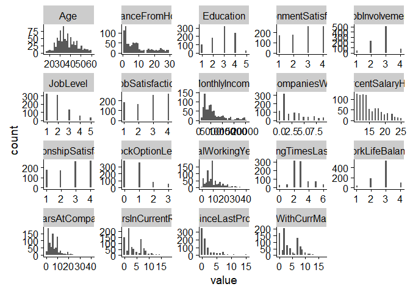

```r
# histogram of all numeric values
emp_clean_numeric.df %>% keep(is.numeric) %>% gather %>% ggplot(aes(x = value)) + facet_wrap(~key, scales = "free")+ geom_histogram()
```

When we plot all the numeric variables against MonthlyIncome, we observe the following:

- Evidence of a strong relationship with JobLevel
- Evidence of a moderate relationship with TotalWorkingYears
- Evidence of a moderate relationship with YearsAtCompany
- Evidence of a moderate relationship with YearsInCurrentRole

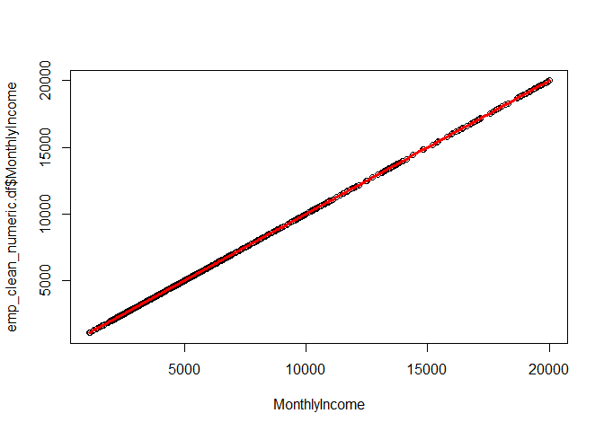

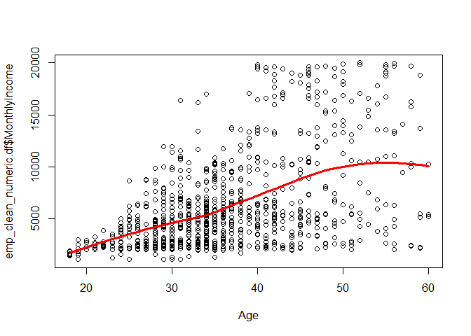

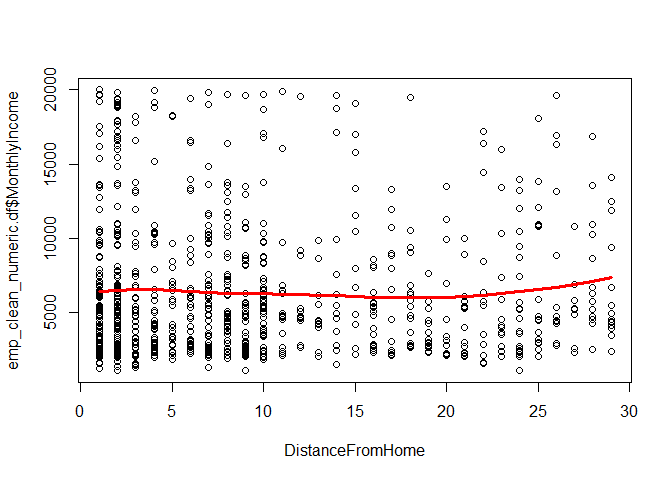

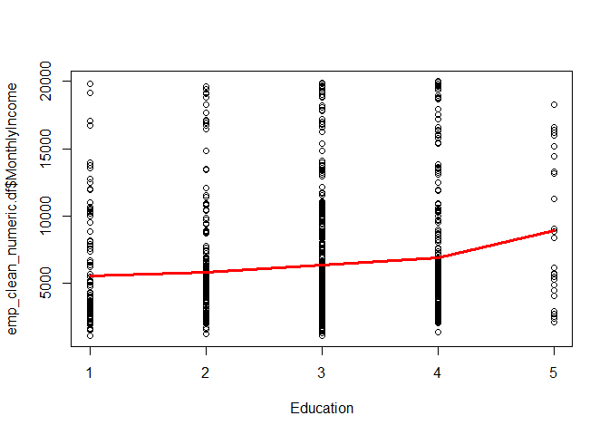

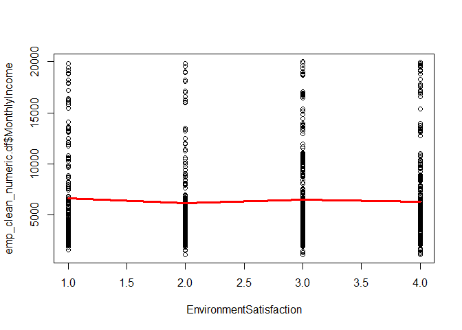

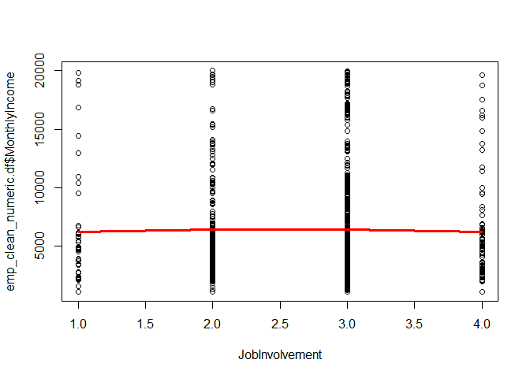

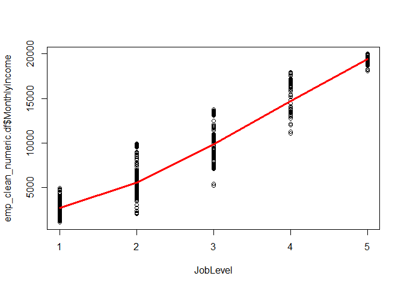

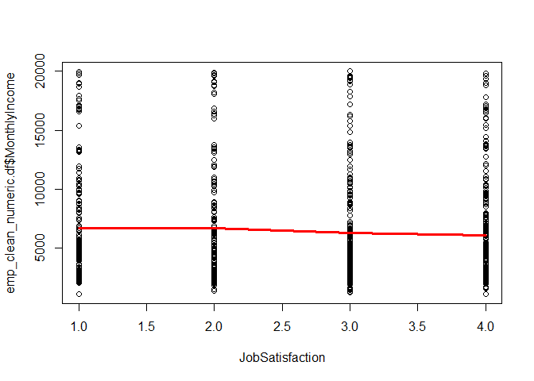

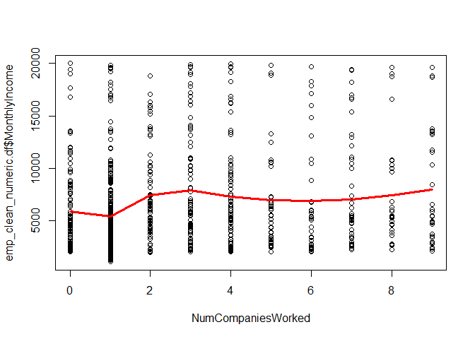

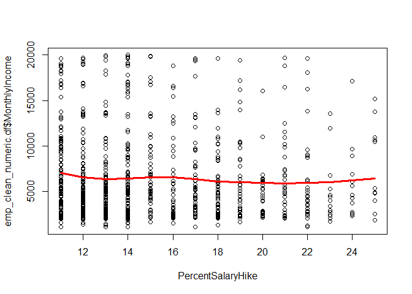

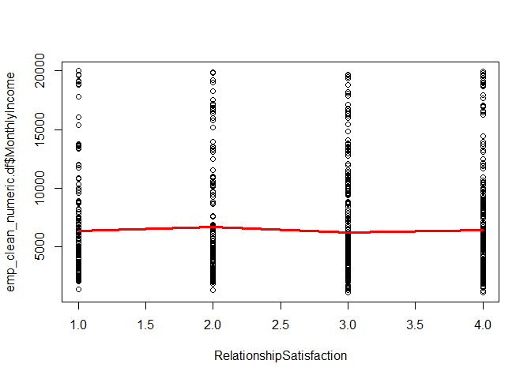

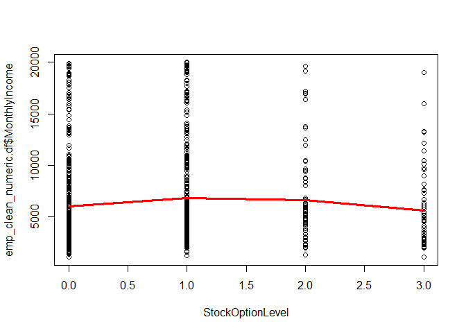

[7 more figures not shown]

```r
plot_vs_response <- function(x){
  plot(emp_clean_numeric.df$MonthlyIncome ~ emp_clean_numeric.df[[x]], xlab = x)
  lw1 <- loess(emp_clean_numeric.df$MonthlyIncome ~ emp_clean_numeric.df[[x]])
  j <- order(emp_clean_numeric.df[[x]])
  lines(emp_clean_numeric.df[[x]][j],lw1$fitted[j],col="red",lwd=3)
}

# Lapply on all xnames values and assing to list object
# plot all numeric variables as x vs response with lapply
# use numNames vector previously defined

lapply(numNames, plot_vs_response)
```

### Categorical Variables

```r
# Defining Plot Function
catplot <- function(df, x,y){
  ggplot(data = df, aes_string(x = x, fill = y)) +
    geom_bar(position = "fill", alpha = 0.9) +
    coord_flip()
}
```

*Annual Income*

The breakdown of annual income shows a reasonably even distribution for the different income categories. The largest delta that exist is the 145 employees that make under 30k per year and the 298 that make between 30k to 60k. While it is about twice as much that is still within acceptable parameters for most models

```r
# AnnualIncome: Total Breakdown
count(emp_clean_factor.df, AnnualIncome)
```

```
## # A tibble: 4 x 2
##   AnnualIncome     n
##   <fctr>       <int>
## 1 Under_30k      145
## 2 30k_to_60k     298
## 3 60k_to_90k     191
## 4 Over_90k       236
```

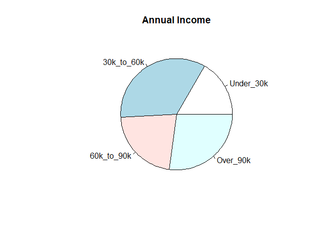

```r
# Pie chart
pie(
  count(emp_clean_factor.df, AnnualIncome)$n,
  labels = count(emp_clean_factor.df, AnnualIncome)$AnnualIncome,
  main = "Annual Income"
)
```

Looking at a comparision of each the categorical variables for the different levels of AnnualIncome, we can see the following:

- JobRoles for “Research Director” and “Manager” have almost exclusively higher annual salaries of over $90,000
- JobRoles for “Healthcare Representative,” “Manufacturing Director,” and “Sales Executive” have no employees making under $30,00 per year
- JobRoles for “Lab Technician,” “Sales Rep,” “Research Scientist” have almost no employees in the over $90,000 category

Most of the other categories were fairly evenly distributed. Thus for predicting salary the JobRole will likely be a critical factor.

[figure not shown]

```r
# Excluding Attrition and AnnualIncome
xnames <- catNames[-c(1,9)]

# Lapply on all xnames values and assing to list object
catplot.list <-lapply(xnames, function(x) catplot(emp_clean_factor.df,x, "AnnualIncome"))
# output plot grid
cowplot::plot_grid(plotlist = catplot.list)
```

*Attrition*

There are significantly more employees that do not leave their companies vs the ones that do: 730 “No” vs only 140 “Yes.” Thus we just need to keep this in mind as we look for changes in the ratios or percentages rather than the raw numbers themselves.

```r
# Attrition: Total Breakdown
count(emp_clean_factor.df, Attrition)
```

```
## # A tibble: 2 x 2
##   Attrition     n
##   <fctr>    <int>
## 1 No          730
## 2 Yes         140
```

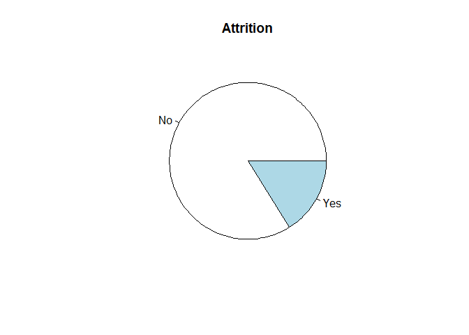

```r
# Pie chart
pie(
  count(emp_clean_factor.df, Attrition)$n,
  labels = count(emp_clean_factor.df, Attrition)$Attrition,
  main = "Attrition"
)
```

Looking at a comparision of each the categorical variables for “Yes” vs “No” Attrition, we can see significant differences for the following:

- OverTime category for “Yes”
- JobRole category for “Sales Representative”
- MaritalStatus category for “Single”
- AnnualIncome category for “Under_30k”

[figure not shown]

```r
# Excluding Attrition
xnames <- catNames[-1]

# Lapply on all xnames values and assing to list object
catplot.list <-lapply(xnames, function(x) catplot(emp_clean_factor.df,x, "Attrition"))
# output plot grid
cowplot::plot_grid(plotlist = catplot.list)
```